# Homework 2

Predicting density-dependent growth of Eurasian collared-doves

KEY

**Due before 2:30pm Monday February 4**

In this homework assignment, you will become more familiar with using `R` and R Markdown to analyze and visualize data and report your results. To accomplish these goals, we will continue our discussion of estimating population growth.

First, make sure you have:

> 1a) Changed the `author` field in the YAML header to your name; **1pt**

> 1b) Clicked `Knit` to check that you can create a html document from the .Rmd file;

> 1c) Save the .Rmd file as `LastnameFirstname-homework2.Rmd` in a directory named `LastNameFirstName-Homework2` **1pt**

If you have any problems with these steps, be sure to get help from either the instructor or the TA.

# Predicting future population size

In [lab 2](https://rushinglab.github.io/WILD3810/articles/lab2.html), we used the exponential growth model to predict the future number of Eurasian collared-doves along Breeding Bird Survey routes in the state of Utah. Based on the rapid growth of this species over the past decade, this model predicted that there will be, on average, over 14,000 collared-doves at each BBS route by the year 2035.

Obviously, the exponential model does not provide a realistic projection of population growth for this species. In this homework, you will use a different model to predict the future size of the collared-dove population.

## Density-dependent population growth

In [lecture 4](https://rushinglab.github.io/WILD3810/articles/Lecture4/Lecture4.html#1), we learned about an extension of the density-independent growth model called the **logistic growth model**:

$$\Large \frac{dN}{dt} = N \times r_0 \bigg(1-\frac{N}{K}\bigg)$$

where $r_0$ is the intrinsic rate of population growth (the rate when there is nothing limiting population growth) and $K$ is the carrying capacity. The logistic growth model indicates the number of individuals added to the population over a very small time period and is therefore most suited for **birth-flow** species (species that reproduce throughout the year). As population size approaches the carrying capacity, the population growth rate approaches 0, setting an upper-limit to population size.

The **Ricker model** is the discrete time version of the logistic growth model and is more appropriate for **birth-pulse** species that have distinct breeding seasons:

$$\Large N_{t+1}=N_t e^{\bigg[r_0\bigg(1 - \frac{N_t}{K}\bigg)\bigg]}$$

> 2. Which model do you think is more appropriate for modeling the dynamics of Eurasian collared-doves? Explain your answer below in **bold**. **4pts**

**Ricker model because 1) doves reproduce during discrete breeding season each summer; 2) BBS surveys are done once per year. Partial credit (2 pts max) possible for answering logistic model with some reasonable demonstration of understandign what that model does and attempting to link to dove ecology**

If you need to know more about this species to answer this question, refer to this overview of [their ecology](https://www.allaboutbirds.org/guide/Eurasian_Collared-Dove/lifehistory)

## Eurasian collared-dove growth in the Eastern US

Both the logistic and Ricker models have the same underlying parameters - $r_0$ and $K$. Therefore, to use either model to predict population growth of collared-doves in Utah, we need estimates of these two quantities.

Because collared-doves do not appear to have reached their carrying capacity in Utah, we cannot use the Utah data to estimate $K$. However, in the eastern United States, collared-dove population growth does appear to have leveled off (they were originally introduced to the US in Florida so eastern populations have had more time to reach $K$). Data on the eastern counts is stored in a separate data frame:

```r
data("all_dove_counts")
```

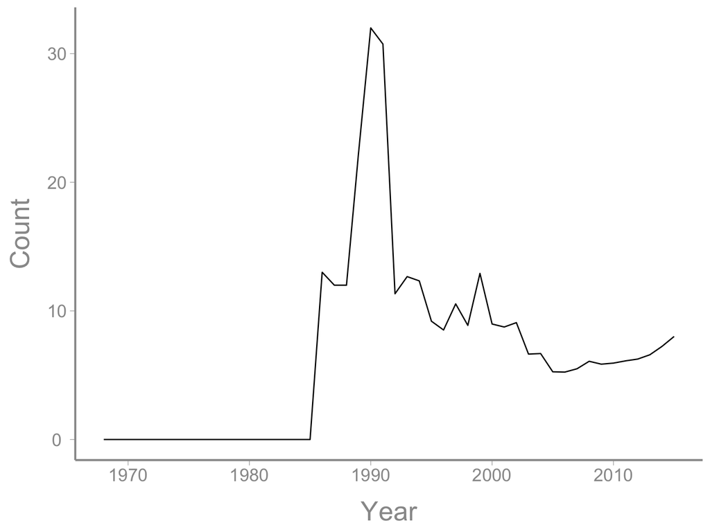

Average count of Eurasian collared-doves at BBS routes in the eastern United States

As we saw in the Utah counts, the population increased rapidly after introduction but eventually stopped increasing and has remained relatively stable since the mid-1990’s. We will use these data to estimate $r_0$ and $K$ (assuming that these parameters are the same or at least similar for doves in Utah and the eastern US).

> 3. What might be some reasons that the dove populations in the eastern US stopped growing once they reached their carrying capacity? In other words, what factors might limit population growth at large population sizes? Provide your answer below in **bold** **4pts**

### Plotting the relationship between $r_0$, $K$, and $N$

Notice that we can re-arrange the Ricker growth model as follows:

$$\Large log\Bigg(\frac{N_{t+1}}{N_t}\Bigg) = r_0 -\frac{r_0}{K}N \tag{1}$$

Also notice that this the equation for a line with y-intercept $=r_0$ and slope $=-\frac{r_0}{K}$. If we can plot $log\Bigg(\frac{N_{t+1}}{N_t}\Bigg)$ as a function of $N$, then a simple way to estimate the growth rate and carrying capacity is to choose values of $r_0$ and $K$ that correspond to a line that passes through these points.

The first step in this process is to estimate $log\Bigg(\frac{N_{t+1}}{N_t}\Bigg)$ for each year of data.

In the chunk below, do the following:

> 4a) Complete the `mutate()` arguments to create a new column in the data frame called `logN` and fill the columns with `NA` (uncomment the line after you are done so R will run the code) **2pts**

> 4b) Complete the `for` loop code to estimate `logN` in each year. Remember that `logN[t]= Count[t+1] / Count[t]`. Use that relationship to change the `?`’s in `all_dove_counts$Count[?]` and `all_dove_counts$Count[?]` to the correct indexes. Also remember that we cannot estimate `logN` in the last year because we don’t know $N_{t+1}$. Use that to change the `?` in `for(t in 1:?)` to correct upper limit for the loop (uncomment all lines in the loop after you are done so R will run the code). **3pts**

```r
library(dplyr)
all_dove_counts <- mutate(all_dove_counts, logN = NA)

for(t in 1:nrow(all_dove_counts)-1){ # hard coding 47 also ok
  all_dove_counts$logN[t] <- log(all_dove_counts$Count[t+1] / all_dove_counts$Count[t])
}
```

Now we can plot `logN` vs. `N` and choose values of $r_0$ and $K$. In the chunk below:

> 5a) Complete the `ggplot()` function so that `Count` is plotted on the x-axis and `logN` is plotted on the y-axis (uncomment the code so R will run it) **2pts**

Notice that the red line does not pass through the middle of the points. You can change the slope and intercept of the line by changing the values of `r0` and `K` and recreating the plot.

> 5b) Choose values of `r0` and `K` that correspond to a line that passes approximately through the middle of the points **2pts**

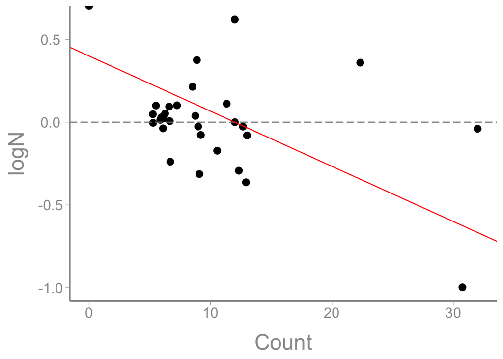

```r
r0 <- 0.4
K <- 12
ggplot(all_dove_counts, aes(x = Count, y = logN)) + geom_point() +
  geom_hline(yintercept = 0, linetype = "longdash", color = "grey50") +
  geom_abline(slope = -r0/K, intercept = r0, color = "red")
```

> 5c) What do you predict the population size of collared-doves will be in Utah in 2035? Explain your answer in **bold** below **2pt**

**Should be same as their chosen value of `K`. Answer should reference carrying capacity being the largest population size the environment can maintain (or along those lines)**

Now modify the code from lab 2 to predict the future dynamics of collared-doves in Utah (uncomment all lines so that `R` will run them once you have filled in the missing parts):

> 6a) Create a new data frame called `predicted_doves` and give it two columns: `Year` and `Count`. `Year` should be a sequence from 2015-2035 and `Count` should be NA **1pt**

> 6b) Assign the first count in `predicted_doves` the value of the last count in `ut_dove_counts` **1pt**

> 6c) Fill in the upper and lower index values inside of `for(t in ?:?)`. Hint: Remember that we already filled in `Count[1]` so what row of the data frame should the loop start on? **1pt**

> 6d) Next fill in the formula for `r` as a function `Count` using equation 1 above (be sure you use square brackets and the correct indexing value to use the correct `Count` in this formula) **2pt**

> 6e) Finally, multiply the current count (`Count[t-1]`) by the proper growth rate to predict `Count[t]`. Hint - remember that you estimated `r` in each loop but we are using a discrete population model based on $\lambda$. **2pt**

```r
data("ut_dove_counts")

predicted_doves <- data.frame(Year = seq(from = 2015, to = 2035),
                              Count = NA)

predicted_doves$Count[1] <- ut_dove_counts$Count[nrow(ut_dove_counts)] # Hard coding ok

for(t in 2:21){
 r <- r0 - (r0/K) * predicted_doves$Count[t-1]
 predicted_doves$Count[t] <- predicted_doves$Count[t-1] * exp(r)
}
```

Modify the following code to:

> 7a) Filter only years greater than 2015 in the `predicted_doves` data frame **1pt**

> 7b) Add a column called `Type` to both data frames and give that variable a value of `Predicted` in `predicted_doves` and `Count` in `ut_doves_counts` **1pt**

> 7c) Complete the `bind_rows()` function to create a new data frame with both the actual and predicted counts **1pt**

```r
predicted_doves <- filter(predicted_doves,Year > 2015)
predicted_doves <- mutate(predicted_doves, Type = "Predicted")
ut_dove_counts <- mutate(ut_dove_counts, Type = "Count")

all_doves <- bind_rows(ut_dove_counts, predicted_doves)
```

Finally, modify the following code to:

> 8a) Fill in the missing `x=`, `y=`, `geom_?`’s, and `color=` to recreate the figure you made in lab 2. Uncomment the lines so the code will run. **4pt**

> 8b) Explain why `color =` goes outside the `aes()` function in the first and second geoms but inside `aes()` in the third. Answer in **bold** below **2pt**

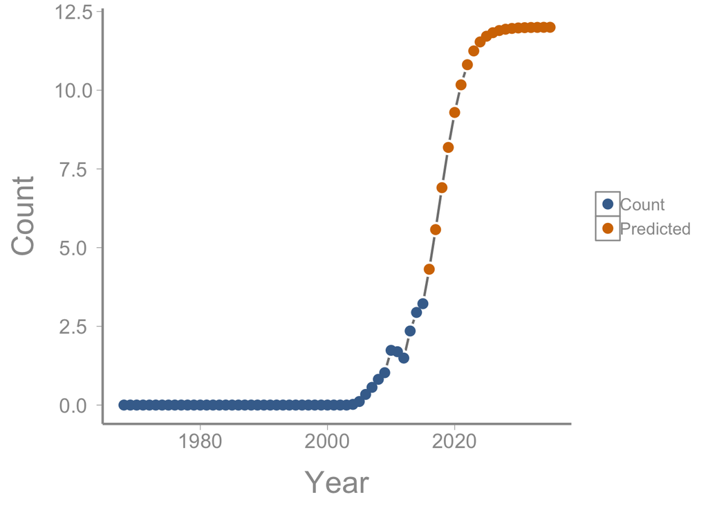

```r
ggplot(data = all_doves, aes(x = Year, y = Count)) + geom_line(color = "grey50") +
  geom_point(color = "white", size = 4.5) + geom_point(aes(color = Type), size = 3)
```

> 9. In approximately what year to you predict the population will reach it’s carrying capacity? Write your answer below in **bold** **3pts**

**Answer will depend on `r0` and `K` but should be close to whatever year in shown in the previous figure**